# NBA Analysis

Aaron Grenz and Marie Marshall

# 1. Free throws versus minutes per game.

This graph displays the free throw percentage versus minutes per game. The data was obtained from the NBAdata set. Years, minutes per game, rebounds per game, and free throw percentage were selected from the data set. Next, we filtered the data by selecting players who played greater than seven years and who had less than three rebounds per game. The graph shows a positive correlation between free throw percentage and the amount of minutes per game. The correlation coefficient for this data is 0.429.

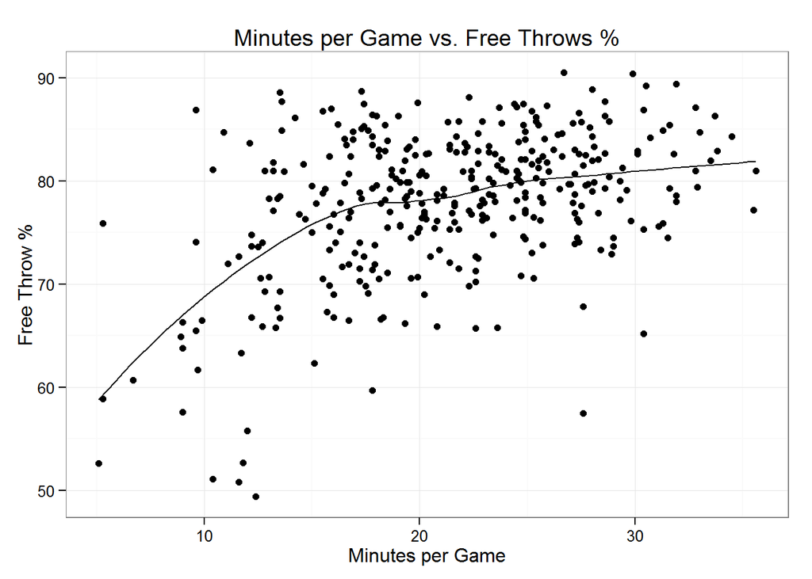

# 2. Sales of teams for each division across the decades.

This graph displays the sales of teams in each division across several decades. The data was obtained from NBAsales data set. Inflation was taken into account by converting the sales prices to 2014 dollar amounts. Even with the value of the dollar the same across all decades, there is a spike in the overall total sale dollars. This can be attributed to a higher interest in NBA basketball and more money being funneled into league.

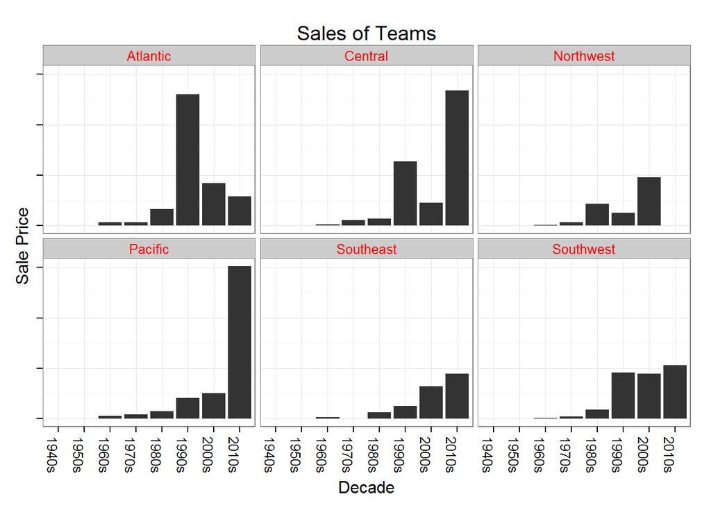